# Reproducible Research - Peer Assignment 1

Patricia

*General Options*

```r
library(knitr)
opts_chunk$set(echo=TRUE)
currDatetime <- format(Sys.time(), "%a %b %d %X %Y")
```

*This document was generated on Sun Aug 16 7:08:50 PM 2015*

# Introduction

*This introduction was taken from the Peer Assignment 1 for the class Reproducible Research offered in Coursera by Johns Hopkins Bloomberg School of Public Health*

It is now possible to collect a large amount of data about personal movement using activity monitoring devices such as a [Fitbit](http://www.fitbit.com), [Nike Fuelband](http://www.nike.com/us/en_us/c/nikeplus-fuelband), or [Jawbone Up](https://jawbone.com/up). These type of devices are part of the “quantified self” movement – a group of enthusiasts who take measurements about themselves regularly to improve their health, to find patterns in their behavior, or because they are tech geeks. But these data remain under-utilized both because the raw data are hard to obtain and there is a lack of statistical methods and software for processing and interpreting the data.

This assignment makes use of data from a personal activity monitoring device. This device collects data at 5 minute intervals through out the day. The data consists of two months of data from an anonymous individual collected during the months of October and November, 2012 and include the number of steps taken in 5 minute intervals each day.

#### Data

- Dataset: [Activity monitoring data](https://d396qusza40orc.cloudfront.net/repdata%2Fdata%2Factivity.zip) [52K]

The variables included in this dataset are:

- **steps**: Number of steps taking in a 5-minute interval (missing values are coded as `NA`)
- **date**: The date on which the measurement was taken in YYYY-MM-DD format
- **interval**: Identifier for the 5-minute interval in which measurement was taken

The dataset is stored in a comma-separated-value (CSV) file and there are a total of 17,568 observations in this dataset.

# The Assignment

The assignment was organized in five parts, each of them developed in this document.

- Part 1: Loading and preprocessing the data
- Part 2: What is mean total number of steps taken per day?
- Part 3: What is the average daily activity pattern?
- Part 4: Imputing missing values
- Part 5: Are there differences in activity patterns between weekdays and weekends?

*Note: Make sure you set as the working as the directory where you will have the activity.zip file downloaded. All results will be also stored in this directory*

### Part 1: Loading and preprocessing the data

The following R code will load, process and transform the data for the [Activity monitoring data](https://d396qusza40orc.cloudfront.net/repdata%2Fdata%2Factivity.zip) described in the introduction.

After the R code you will find listed the first five rows of the dataset

*Note: I am downloading the file from the source and not using the one provided in GitHub*

```r
# Downloads the file
url <- "https://d396qusza40orc.cloudfront.net/repdata%2Fdata%2Factivity.zip"
setInternet2(use = TRUE)
download.file(url, "repdata-data-activity.zip", mode="wb")

# Unzip the activity.zip file available in the working directory on the same directory
unzip ("repdata-data-activity.zip")

# Reads dataset into the activityDF data fame
activityDF <- read.csv("activity.csv")

# TIDY DATA FOR ANALYSIS
# Calculates the POSIXct object variable corresponding to the factor variable date
# in the dataset to represent it as a datetime and add it as a column to the dataframe
activityDF <- cbind(activityDF,strptime(as.character(activityDF$date),"%Y-%m-%d"))
names(activityDF) <- c("steps","dateAsFactor","interval","date")

# List rows 1 thru 5 of the data set (these rows do not have steps counted)
activityDF[1:5,]
```

```
##   steps dateAsFactor interval       date
## 1    NA   2012-10-01        0 2012-10-01
## 2    NA   2012-10-01        5 2012-10-01
## 3    NA   2012-10-01       10 2012-10-01
## 4    NA   2012-10-01       15 2012-10-01
## 5    NA   2012-10-01       20 2012-10-01
```

```r
# List rows 644 thru 648 of the data set (these rows have steps counted)
activityDF[644:649,]
```

```
##     steps dateAsFactor interval       date
## 644    25   2012-10-03      535 2012-10-03
## 645     0   2012-10-03      540 2012-10-03
## 646     0   2012-10-03      545 2012-10-03
## 647    90   2012-10-03      550 2012-10-03
## 648   411   2012-10-03      555 2012-10-03
## 649   413   2012-10-03      600 2012-10-03
```

### Part 2: What is mean total number of steps taken per day?

In this part we will:

- calculate the **total number of steps per day**,
- display a histogram to understand the distribution of **total number of steps per day** taken by the individual
- and finally, we will calculate the mean and the median for **total number of steps per day**

```r
# aggregates activity data for each date in the dataframe to calculate the total number of steps per day
activityPerDayDF <- aggregate(steps ~ date, activityDF,sum,na.rm=TRUE)

# List rows 1 thru 5 of the data set
activityPerDayDF[1:5,]
```

```
##         date steps
## 1 2012-10-02   126
## 2 2012-10-03 11352
## 3 2012-10-04 12116
## 4 2012-10-05 13294
## 5 2012-10-06 15420
```

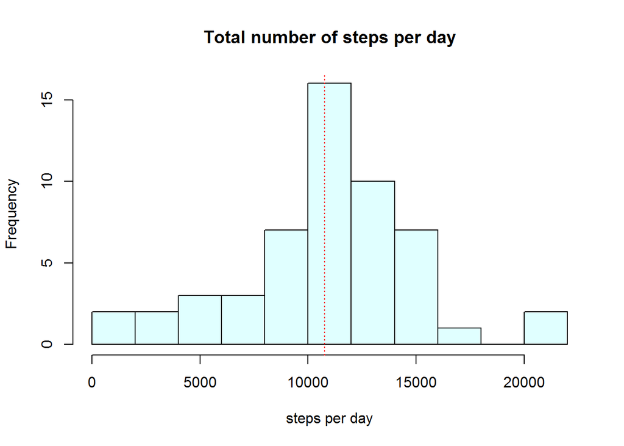

```r
# display a histogram to understand the distribution of total number of steps per day taken by the individual
hist(activityPerDayDF[,"steps"],
     col = "lightcyan",
     main = "Total number of steps per day",
     xlab = "steps per day",
     ylab = "Frequency",
     breaks= 9,
     mar = c(2,3,2,2))
# display a vertical line to show the mean of the total number of steps per day taken by the individual
abline(v=mean(activityPerDayDF$steps),col="red",lty=3)
```

```r
# calculate the mean and the median for total number of steps per day and other interesting statistics
summary(activityPerDayDF$steps)
```

```
##    Min. 1st Qu.  Median    Mean 3rd Qu.    Max.
##      41    8841   10760   10770   13290   21190
```

### Part 3: What is the average daily activity pattern?

In this part we will start by calculating the average number of steps taken for each 5 minute interval across all days (ignoring NAs) and then we will plot a time series for the intervals. Finally, we will show some intersting statisitics

```r
# aggregates activity data for each interval in the dataframe to calculate the average number of steps per interval
activityPerIntervalDF <- aggregate(steps ~ interval, activityDF,mean,na.rm=TRUE)

# List rows 1 thru 5 of the data set
activityPerIntervalDF[1:5,]
```

```
##   interval     steps
## 1        0 1.7169811
## 2        5 0.3396226
## 3       10 0.1320755
## 4       15 0.1509434
## 5       20 0.0754717
```

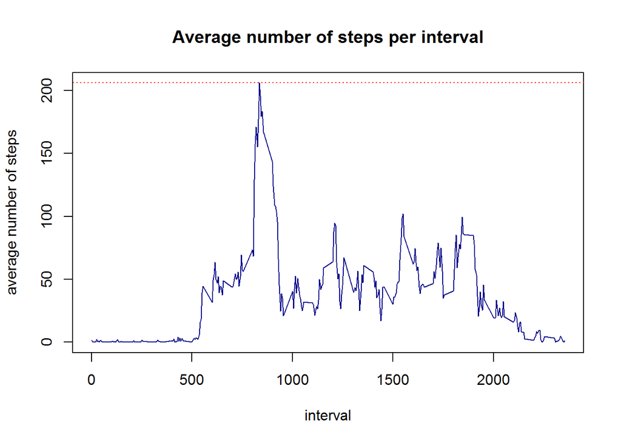

```r
# display a time series to understand the behaviour of average number of steps per interval taken by the individual
plot(x = activityPerIntervalDF$interval,
     y = activityPerIntervalDF$steps,
     type = "l",
     main = "Average number of steps per interval",
     col="darkblue",
     xlab = "interval",
     ylab = "average number of steps",
     mar = c(2,3,2,2))
# display a horizontal line to show the average number of steps maximum value
maxStepsPerInterval <- max(activityPerIntervalDF$steps)
abline(h=maxStepsPerInterval,col="red",lty=3)
```

```r
# calculate the max for average number of steps per interval taken by the individual and other interesting statistics
summary(activityPerIntervalDF$steps)
```

```
##    Min. 1st Qu.  Median    Mean 3rd Qu.    Max.
##   0.000   2.486  34.110  37.380  52.830 206.200
```

```r
# calculate the interval for which the average number of steps took its maximum value
subset(activityPerIntervalDF,steps == maxStepsPerInterval)$interval
```

```
## [1] 835
```

### Part 4: Imputing missing values

After filling all NAs, We will repeat the part 2 of these assignment with the new dataset and will analize the impact

```r
# counts activity data with no value in the number of steps
totRowsNAd<- nrow(subset(activityDF,is.na(steps)))

# NOT-NA DATA FOR ANALYSIS
# Populates a new data frame, activityAdjDF, with same data as activityDF adjusting only steps
#   If steps has not value it will be populated with the mean for the interval

activityAdjDF <- activityDF
activityAdjDF$steps[is.na(activityDF$steps)] <-
        activityPerIntervalDF$steps[activityPerIntervalDF$interval==
                                            activityDF$interval[is.na(activityDF$steps)]]

# List rows 1 thru 5 of the data set (these rows did not have steps counted and have been adjusted to the mean of the interval)
activityAdjDF[1:5,]
```

```
##       steps dateAsFactor interval       date
## 1 1.7169811   2012-10-01        0 2012-10-01
## 2 0.3396226   2012-10-01        5 2012-10-01
## 3 0.1320755   2012-10-01       10 2012-10-01
## 4 0.1509434   2012-10-01       15 2012-10-01
## 5 0.0754717   2012-10-01       20 2012-10-01
```

```r
# List rows 644 thru 648 of the data set (these rows had steps counted and remain as such)
activityAdjDF[644:649,]
```

```
##     steps dateAsFactor interval       date
## 644    25   2012-10-03      535 2012-10-03
## 645     0   2012-10-03      540 2012-10-03
## 646     0   2012-10-03      545 2012-10-03
## 647    90   2012-10-03      550 2012-10-03
## 648   411   2012-10-03      555 2012-10-03
## 649   413   2012-10-03      600 2012-10-03
```

```r
# aggregates activity data for each date in the dataframe to calculate the total number of steps per day
activityAdjPerDayDF <- aggregate(steps ~ date, activityAdjDF,sum)

# List rows 1 thru 5 of the data set
activityAdjPerDayDF[1:5,]
```

```
##         date    steps
## 1 2012-10-01 10766.19
## 2 2012-10-02   126.00
## 3 2012-10-03 11352.00
## 4 2012-10-04 12116.00
## 5 2012-10-05 13294.00
```

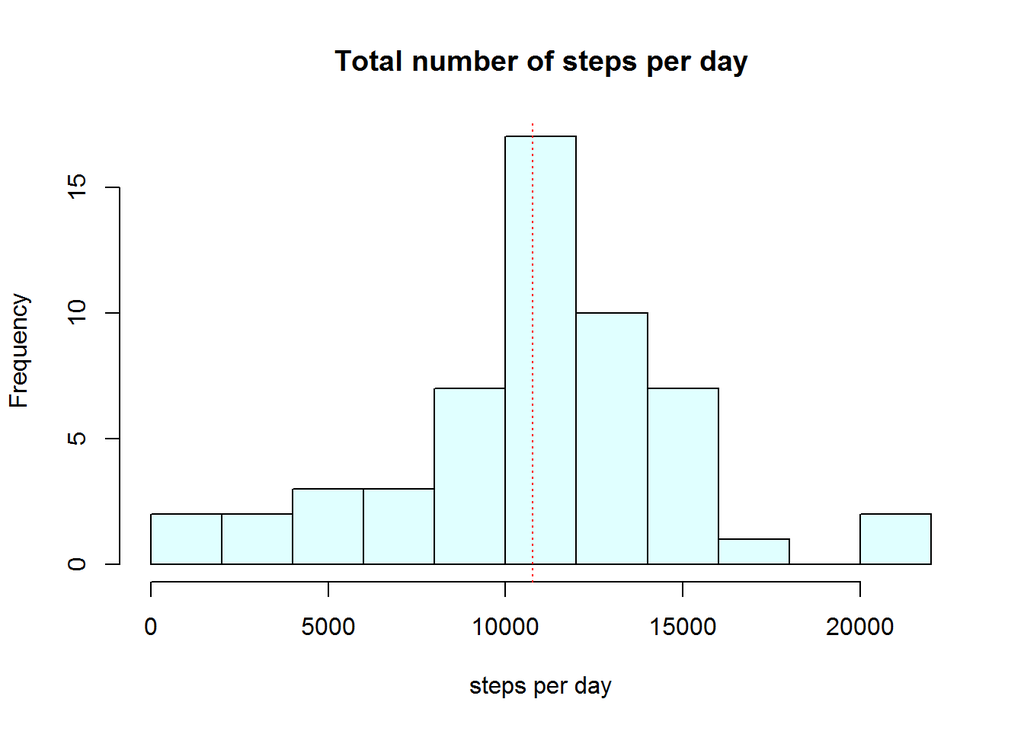

```r
# display a histogram to understand the distribution of total number of steps per day taken by the individual
hist(activityAdjPerDayDF[,"steps"],
     col = "lightcyan",
     main = "Total number of steps per day",
     xlab = "steps per day",
     ylab = "Frequency",
     breaks= 9,
     mar = c(2,3,2,2))
# display a vertical line to show the mean of the total number of steps per day taken by the individual
abline(v=mean(activityAdjPerDayDF$steps),col="red",lty=3)
```

```r
# calculate the mean and the median for total number of steps per day and other interesting statistics
compareStats <- rbind(summary(activityPerDayDF$steps),summary(activityAdjPerDayDF$steps))
rownames(compareStats) <- c("original","adjusted")

perctgDiff <- round(100*abs(compareStats[1,] - compareStats[2,])/
                            (compareStats[1,] + compareStats[2,]),3)

compareStats
```

```
##          Min. 1st Qu. Median  Mean 3rd Qu.  Max.
## original   41    8841  10760 10770   13290 21190
## adjusted   41    8860  10770 10770   13190 21190
```

```r
perctgDiff
```

```
##    Min. 1st Qu.  Median    Mean 3rd Qu.    Max.
##   0.000   0.107   0.046   0.000   0.378   0.000
```

My conclusion is that the impact is not significant due to the difference in percentage on the statistics summary presented in the last result

### Part 5: Are there differences in activity patterns between weekdays and weekends?

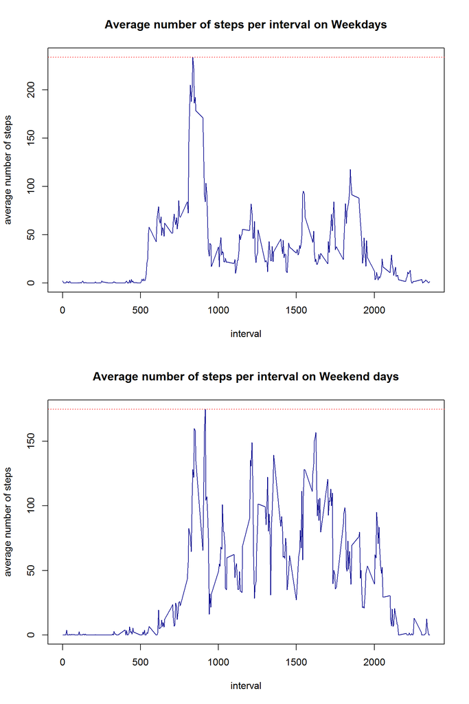

```r
# add a column with the datype to the data frame, activityAdjDF (this data frane does not have NA values
# in the steps variable as they have been populated with the mean fro the iteration)

dayType <- c("weekday","weekday","weekday","weekday","weekday","weekend","weekend")
TypeOfDay <- dayType[as.numeric(format(activityAdjDF$date,"%u"))]
activityAdjDF <- cbind(activityAdjDF,TypeOfDay)

# aggregates activity data for each interval in the dataframe to calculate the average number of steps per interval for weekdays
activityWeekdayPerIntervalDF <- aggregate(steps ~ interval,
                                   subset(activityDF,TypeOfDay=="weekday"),mean)

# aggregates activity data for each interval in the dataframe to calculate the average number of steps per interval for weekend days
activityWeekendPerIntervalDF <- aggregate(steps ~ interval,
                                   subset(activityDF,TypeOfDay=="weekend"),mean)

# display two time series to understand the behaviour of average number of steps per interval taken by the individual on weekdays vs. weekends

## Create 2 plot areas
par(mfcol = c(2,1))

plot(x = activityWeekdayPerIntervalDF$interval,
     y = activityWeekdayPerIntervalDF$steps,
     type = "l",
     main = "Average number of steps per interval on Weekdays",
     col="darkblue",
     xlab = "interval",
     ylab = "average number of steps")
# display a horizontal line to show the average number of steps maximum value
maxStepsWeekdayPerInterval <- max(activityWeekdayPerIntervalDF$steps)
abline(h=maxStepsWeekdayPerInterval,col="red",lty=3)

plot(x = activityWeekendPerIntervalDF$interval,
     y = activityWeekendPerIntervalDF$steps,
     type = "l",
     main = "Average number of steps per interval on Weekend days",
     col="darkblue",
     xlab = "interval",
     ylab = "average number of steps")
# display a horizontal line to show the average number of steps maximum value
maxStepsWeekendPerInterval <- max(activityWeekendPerIntervalDF$steps)
abline(h=maxStepsWeekendPerInterval,col="red",lty=3)
```